# Homework 1

## 3.2) Search Volume of the " Turkey Hotels " Phrase

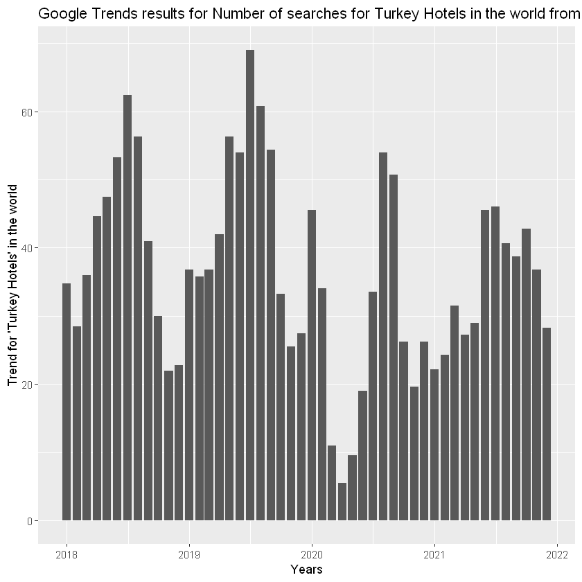

[figure not shown]

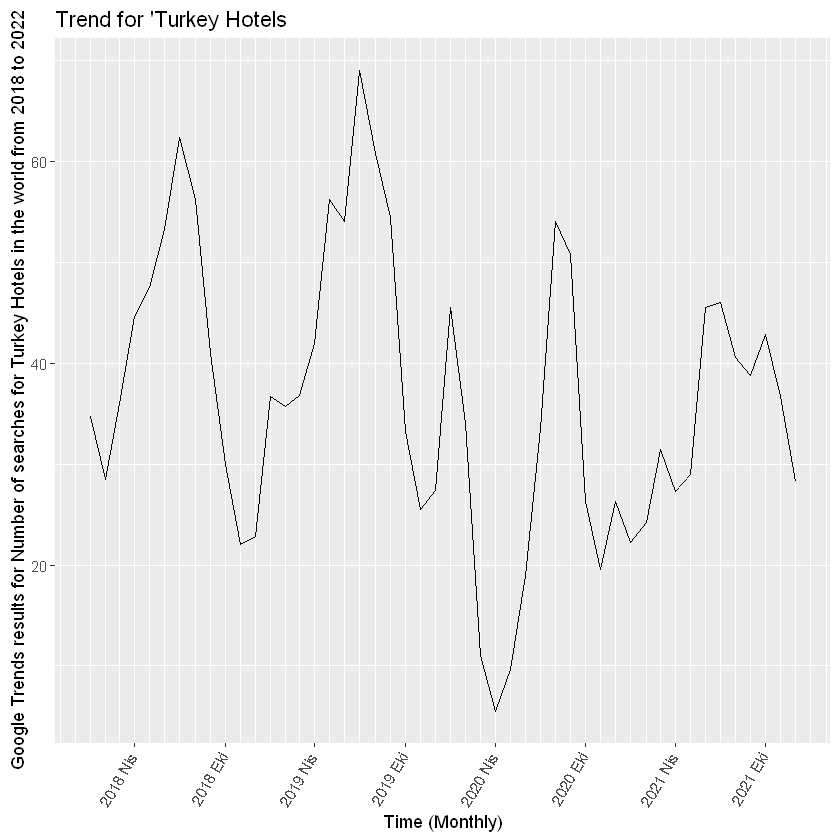

```r
ggplot(google_trends,aes(x=Date,y=Data))+ geom_bar(stat='identity')+
  xlab("Years") + ylab("Trend for 'Turkey Hotels' in the world")+ ggtitle("Google Trends results for Number of searches for Turkey Hotels in the world from 2018 to 2022")

ggplot(google_trends,aes(x=factor(year(Date)),y=Data))+ geom_boxplot(aes(fill=factor(year(Date))))+
  xlab("Years") + ylab("Trend for 'Turkey Hotels' in the world")+ ggtitle("Google Trends results for Number of searches for Turkey Hotels in the world from 2018 to 2022")+
  theme(legend.position = "none")

google_trends %>%
  ggplot(aes(x= Date, y = Data)) +
  geom_line(color = 1) +
  labs(title = "Trend for 'Turkey Hotels", x = "Time (Monthly)", y = "Google Trends results for Number of searches for Turkey Hotels in the world from 2018 to 2022") +
  scale_x_date(date_breaks = "6 month", date_labels = "%Y %b", date_minor_breaks = "1 month") +
  theme(axis.text.x=element_text(angle=60, hjust=1.4, vjust = 1.4))
```

We also see the seasonality effect in the visualization of the search data for the phrase "Turkey Hotels". In addition, we can clearly see the decline due to the pandemic effect in March 2020. We can say that the graph of this data is very similar to the graphs we created with the number of tourists coming to Turkey. Based on this, we can easily deduce that there is a connection between the search for the phrase "Turkey Hotels" on google and the number of tourists visiting Turkey.